# Comparison of TE insertions found on samples reads_LSA-2024-0039_GS1375-I-Sangre and reads_LSA-2024-0040_GS1375-H-Sangre

02 junio, 2025

# Introduction

**Note**: Insertion ids mentioned in this report are for internal use (not linked to any database) and will change if the pipeline is re-run.

## TE insertions in common and not in common

**Note**: To ease readability, insertions present in one sample only (or not in common, as shown in the title above) will be referred as *unshared* insertions.

| Present in N samples | Number of insertions |
| --- | --- |
| 1 | 136 |
| 2 | 1 822 |
| Total | 1 958 |

Out of 1 958 unique TE insertions, 1 822 are found in both samples, while 136 are found only in one of them, **when considering only strict calls**.

### Closer examination

Some of the unshared insertions may be actually present on both samples. If we check also the calls that did not pass the strict criterion, we may alleviate this issue:

| Present in N samples | Number of insertions |
| --- | --- |
| 1 | 54 |
| 2 | 1 904 |
| Total | 1 958 |

# Unshared insertions

After this second examination, 54 are reported as present in one sample only.

## Unshared insertions by class

| Class | Family | Subfamily | Number of insertions |
| --- | --- | --- | --- |
| Class I | DNA | TcMar | 1 |
| Class II | LINE | L1 | 7 |
|  | LTR | ERV1 | 12 |
|  |  | ERVL | 3 |
|  | Retroposon | SVA | 15 |
|  | SINE | Alu | 16 |
| Total | - | - | 54 |

## Annotation of unshared insertions

In the table below is shown the gene annotation for unshared insertions.

**Click to show table with 18 rows.**

**Note**: Annotation type is as described by R package annotatr: “cds”: coding sequences, “promoter”: regulatory region up to 1kb uptream, “1to5kb”: regulatory region between 1 and 5kb upstream, “genes” and “introns”: literal meaning.

| Position | INS Id | Gene symbol | Gene Id | Annotation type |
| --- | --- | --- | --- | --- |
| CP068257.2:44 525 067 | seq96246 | FTCD | NM_001320412.2 | introns |
| CP068259.2:59 334 673 | seq89520 | ZSCAN5A | NM_001322066.2 | introns |
| CP068260.2:50 011 949 | seq86046 | ACAA2 | NM_006111.3 | introns |
| CP068261.2:482 199 | seq81746 | VPS53 | NM_001128159.3 | introns |
| CP068263.2:82 652 649 | seq77870 | SLC28A1 | XM_054379189.1 | introns |
| CP068266.2:56 751 564 | seq65308 | HSD17B6 | XM_054373695.1 | introns |
| CP068266.2:104 285 275 | seq66513 | TXNRD1 | NM_001093771.3 | introns |
| CP068267.2:22 364 248 | seq60932 | ANO5 | XM_054367965.1 | introns |
| CP068267.2:89 743 813 | seq62475 | LOC642414 | NR_169306.1 | introns |
| CP068272.2:34 221 295 | seq31054 | RPS10-NUDT3 | NM_001202470.3 | introns |
| CP068273.2:178 323 193 | seq29297 | FAM153A | NR_146227.2 | introns |
| CP068274.2:16 374 994 | seq19351 | LOC105374505 | XR_007074502.1 | introns |
| CP068274.2:157 545 206 | seq22828 | LOC101927947 | XR_007075095.1 | introns |
| CP068275.2:12 655 079 | seq13997 | RAF1 | XM_054347415.1 | introns |
| CP068275.2:181 924 701 | seq17828 | PIK3CA-DT | NR_125401.1 | introns |
| CP068276.2:152 612 938 | seq11258 | STAM2 | NM_005843.6 | introns |
| CP068276.2:156 904 280 | seq11336 | GPD2 | XM_054341414.1 | introns |
|  | seq11337 | GPD2 | XM_054341414.1 | introns |

## Full list

This is the list of insertions found in only one of the two samples, alongside its allele frequency inside the whole population (all the cases in your pipeline) and which sample it was found in.

**Click to show table with 54 rows.**

| Position | seqId | Length (bp) | Type | Population allele frequency | Present in sample |
| --- | --- | --- | --- | --- | --- |
| CP068255.2:1 651 456 | seq99962 | 76 | LTR (MLT1A0) | 0.50 | reads_LSA-2024-0039_GS1375-I-Sangre |
| CP068255.2:1 651 527 | seq99963 | 77 | LTR (MLT1A0) | 0.50 | reads_LSA-2024-0040_GS1375-H-Sangre |
| CP068255.2:101 554 740 | seq101876 | 378 | LINE (L1P1) | 0.50 | reads_LSA-2024-0039_GS1375-I-Sangre |
| CP068255.2:531 602 | seq99863 | 320 | SINE (AluSx) | 0.25 | reads_LSA-2024-0040_GS1375-H-Sangre |
| CP068256.2:5 970 474 | seq97000 | 59 | SINE (Alu) | 0.50 | reads_LSA-2024-0040_GS1375-H-Sangre |
| CP068256.2:19 536 487 | seq98429 | 86 | LTR (MER49) | 0.25 | reads_LSA-2024-0040_GS1375-H-Sangre |
| CP068257.2:44 525 067 | seq96246 | 153 | LTR (LTR12_v) | 0.25 | reads_LSA-2024-0040_GS1375-H-Sangre |
| CP068258.2:29 086 473 | seq90430 | 1 885 | LINE (L1HS) | 0.25 | reads_LSA-2024-0039_GS1375-I-Sangre |
| CP068259.2:24 646 972 | seq88336 | 310 | SINE (AluY) | 0.50 | reads_LSA-2024-0039_GS1375-I-Sangre |
| CP068259.2:59 334 673 | seq89520 | 140 | LTR (MER51E) | 0.25 | reads_LSA-2024-0040_GS1375-H-Sangre |
| CP068260.2:30 401 142 | seq85580 | 83 | SINE (AluJb) | 0.25 | reads_LSA-2024-0040_GS1375-H-Sangre |
| CP068260.2:50 011 949 | seq86046 | 174 | Retroposon (SVA_F) | 0.25 | reads_LSA-2024-0040_GS1375-H-Sangre |
| CP068261.2:37 220 145 | seq83178 | 335 | SINE (AluYb8) | 0.25 | reads_LSA-2024-0039_GS1375-I-Sangre |
| CP068261.2:44 159 838 | seq83374 | 208 | LTR (HERVIP10FH-int) | 0.25 | reads_LSA-2024-0039_GS1375-I-Sangre |
| CP068261.2:44 305 072 | seq83384 | 395 | Retroposon (SVA_F) | 0.25 | reads_LSA-2024-0040_GS1375-H-Sangre |
| CP068261.2:482 199 | seq81746 | 96 | Retroposon (SVA_F) | 0.25 | reads_LSA-2024-0039_GS1375-I-Sangre |
| CP068262.2:68 772 355 | seq80578 | 62 | LTR (HERVH-int) | 0.50 | reads_LSA-2024-0040_GS1375-H-Sangre |
| CP068262.2:68 772 361 | seq80579 | 62 | LTR (HERVH-int) | 0.50 | reads_LSA-2024-0039_GS1375-I-Sangre |
| CP068263.2:5 431 635 | seq75719 | 314 | SINE (AluYg6) | 0.25 | reads_LSA-2024-0039_GS1375-I-Sangre |
| CP068263.2:82 652 649 | seq77870 | 68 | SINE (FRAM) | 0.25 | reads_LSA-2024-0039_GS1375-I-Sangre |
| CP068263.2:86 307 221 | seq77979 | 146 | Retroposon (SVA_F) | 0.50 | reads_LSA-2024-0039_GS1375-I-Sangre |
| CP068266.2:56 751 564 | seq65308 | 48 | Retroposon (SVA_F) | 0.50 | reads_LSA-2024-0039_GS1375-I-Sangre |
| CP068266.2:70 065 731 | seq65686 | 62 | LTR (HERVH-int) | 0.25 | reads_LSA-2024-0040_GS1375-H-Sangre |
| CP068266.2:104 285 275 | seq66513 | 95 | Retroposon (SVA_C) | 0.25 | reads_LSA-2024-0039_GS1375-I-Sangre |
| CP068267.2:22 364 248 | seq60932 | 1 119 | LINE (L1P4) | 0.25 | reads_LSA-2024-0039_GS1375-I-Sangre |
| CP068267.2:89 743 813 | seq62475 | 56 | LINE (L1P3) | 0.50 | reads_LSA-2024-0039_GS1375-I-Sangre |
| CP068269.2:39 752 595 | seq45002 | 327 | SINE (AluY) | 0.50 | reads_LSA-2024-0039_GS1375-I-Sangre |
| CP068269.2:41 490 840 | seq45041 | 88 | SINE (AluYc) | 0.25 | reads_LSA-2024-0040_GS1375-H-Sangre |
| CP068269.2:41 696 039 | seq45048 | 85 | LINE (L1P4b) | 0.50 | reads_LSA-2024-0040_GS1375-H-Sangre |
| CP068270.2:2 088 213 | seq40444 | 135 | LINE (L1P1) | 0.50 | reads_LSA-2024-0039_GS1375-I-Sangre |
| CP068270.2:2 170 735 | seq40457 | 133 | LINE (L1P1) | 0.25 | reads_LSA-2024-0040_GS1375-H-Sangre |
| CP068270.2:129 246 415 | seq43406 | 202 | Retroposon (SVA_A) | 0.25 | reads_LSA-2024-0039_GS1375-I-Sangre |
| CP068272.2:31 707 361 | seq30804 | 579 | Retroposon (SVA_F) | 0.25 | reads_LSA-2024-0039_GS1375-I-Sangre |
| CP068272.2:32 339 964 | seq30849 | 136 | SINE (AluSx4) | 0.25 | reads_LSA-2024-0040_GS1375-H-Sangre |
| CP068272.2:32 344 914 | seq30855 | 281 | SINE (AluY) | 0.25 | reads_LSA-2024-0040_GS1375-H-Sangre |
| CP068272.2:34 221 295 | seq31054 | 49 | Retroposon (SVA_F) | 0.25 | reads_LSA-2024-0040_GS1375-H-Sangre |
| CP068273.2:178 323 193 | seq29297 | 93 | DNA (Tigger2a) | 0.25 | reads_LSA-2024-0040_GS1375-H-Sangre |
| CP068273.2:182 041 536 | seq29590 | 319 | SINE (AluYb8) | 0.25 | reads_LSA-2024-0040_GS1375-H-Sangre |
| CP068274.2:4 318 463 | seq18909 | 64 | LTR (LTR12) | 0.25 | reads_LSA-2024-0039_GS1375-I-Sangre |
| CP068274.2:16 374 994 | seq19351 | 72 | Retroposon (SVA_D) | 0.25 | reads_LSA-2024-0040_GS1375-H-Sangre |
| CP068274.2:138 729 775 | seq22367 | 393 | LTR (LTR12C) | 0.25 | reads_LSA-2024-0040_GS1375-H-Sangre |
| CP068274.2:157 545 206 | seq22828 | 74 | LTR (MSTC) | 0.25 | reads_LSA-2024-0039_GS1375-I-Sangre |
| CP068275.2:12 655 079 | seq13997 | 175 | Retroposon (SVA_F) | 0.25 | reads_LSA-2024-0039_GS1375-I-Sangre |
| CP068275.2:147 504 056 | seq17023 | 76 | LTR (LTR12D) | 0.50 | reads_LSA-2024-0039_GS1375-I-Sangre |
| CP068275.2:181 924 701 | seq17828 | 49 | Retroposon (SVA_F) | 0.25 | reads_LSA-2024-0040_GS1375-H-Sangre |
| CP068276.2:7 901 998 | seq7644 | 54 | LTR (HERVH-int) | 0.50 | reads_LSA-2024-0040_GS1375-H-Sangre |
| CP068276.2:7 902 007 | seq7645 | 55 | LTR (HERVH-int) | 0.50 | reads_LSA-2024-0039_GS1375-I-Sangre |
| CP068276.2:152 612 938 | seq11258 | 173 | Retroposon (SVA_F) | 0.25 | reads_LSA-2024-0040_GS1375-H-Sangre |
| CP068276.2:156 904 280 | seq11336 | 49 | Retroposon (SVA_F) | 0.50 | reads_LSA-2024-0040_GS1375-H-Sangre |
| CP068276.2:156 904 280 | seq11337 | 49 | Retroposon (SVA_F) | 0.50 | reads_LSA-2024-0039_GS1375-I-Sangre |
| CP068277.2:24 473 073 | seq1133 | 312 | SINE (AluSx) | 0.25 | reads_LSA-2024-0039_GS1375-I-Sangre |
| CP068277.2:24 473 164 | seq1134 | 312 | SINE (AluSx) | 0.25 | reads_LSA-2024-0040_GS1375-H-Sangre |
| CP068277.2:143 216 324 | seq4371 | 313 | SINE (AluY) | 0.25 | reads_LSA-2024-0039_GS1375-I-Sangre |
| CP086569.2:1 199 242 | seq103209 | 157 | SINE (AluSx) | 0.50 | reads_LSA-2024-0039_GS1375-I-Sangre |

# Shared by Sample

## Sample1

**Click to show unique insertions in reads_LSA-2024-0039_GS1375-I-Sangre (28 rows)**

Inserciones unicas en reads_LSA-2024-0039_GS1375-I-Sangre

| Position | INS Id | Length (bp) | Type | Population allele frequency |
| --- | --- | --- | --- | --- |
| CP068255.2:1 651 456 | seq99962 | 76 | LTR (MLT1A0) | 0.50 |
| CP068255.2:101 554 740 | seq101876 | 378 | LINE (L1P1) | 0.50 |
| CP068258.2:29 086 473 | seq90430 | 1 885 | LINE (L1HS) | 0.25 |
| CP068259.2:24 646 972 | seq88336 | 310 | SINE (AluY) | 0.50 |
| CP068261.2:37 220 145 | seq83178 | 335 | SINE (AluYb8) | 0.25 |
| CP068261.2:44 159 838 | seq83374 | 208 | LTR (HERVIP10FH-int) | 0.25 |
| CP068261.2:482 199 | seq81746 | 96 | Retroposon (SVA_F) | 0.25 |
| CP068262.2:68 772 361 | seq80579 | 62 | LTR (HERVH-int) | 0.50 |
| CP068263.2:5 431 635 | seq75719 | 314 | SINE (AluYg6) | 0.25 |
| CP068263.2:82 652 649 | seq77870 | 68 | SINE (FRAM) | 0.25 |
| CP068263.2:86 307 221 | seq77979 | 146 | Retroposon (SVA_F) | 0.50 |
| CP068266.2:56 751 564 | seq65308 | 48 | Retroposon (SVA_F) | 0.50 |
| CP068266.2:104 285 275 | seq66513 | 95 | Retroposon (SVA_C) | 0.25 |
| CP068267.2:22 364 248 | seq60932 | 1 119 | LINE (L1P4) | 0.25 |
| CP068267.2:89 743 813 | seq62475 | 56 | LINE (L1P3) | 0.50 |
| CP068269.2:39 752 595 | seq45002 | 327 | SINE (AluY) | 0.50 |
| CP068270.2:2 088 213 | seq40444 | 135 | LINE (L1P1) | 0.50 |
| CP068270.2:129 246 415 | seq43406 | 202 | Retroposon (SVA_A) | 0.25 |
| CP068272.2:31 707 361 | seq30804 | 579 | Retroposon (SVA_F) | 0.25 |
| CP068274.2:4 318 463 | seq18909 | 64 | LTR (LTR12) | 0.25 |
| CP068274.2:157 545 206 | seq22828 | 74 | LTR (MSTC) | 0.25 |
| CP068275.2:12 655 079 | seq13997 | 175 | Retroposon (SVA_F) | 0.25 |
| CP068275.2:147 504 056 | seq17023 | 76 | LTR (LTR12D) | 0.50 |
| CP068276.2:7 902 007 | seq7645 | 55 | LTR (HERVH-int) | 0.50 |
| CP068276.2:156 904 280 | seq11337 | 49 | Retroposon (SVA_F) | 0.50 |
| CP068277.2:24 473 073 | seq1133 | 312 | SINE (AluSx) | 0.25 |
| CP068277.2:143 216 324 | seq4371 | 313 | SINE (AluY) | 0.25 |
| CP086569.2:1 199 242 | seq103209 | 157 | SINE (AluSx) | 0.50 |

## Sample2

**Click to show unique insertions in reads_LSA-2024-0040_GS1375-H-Sangre (26 rows)**

Inserciones unicas en reads_LSA-2024-0040_GS1375-H-Sangre

| Position | INS Id | Length (bp) | Type | Population allele frequency |
| --- | --- | --- | --- | --- |
| CP068255.2:1 651 527 | seq99963 | 77 | LTR (MLT1A0) | 0.50 |
| CP068255.2:531 602 | seq99863 | 320 | SINE (AluSx) | 0.25 |
| CP068256.2:5 970 474 | seq97000 | 59 | SINE (Alu) | 0.50 |
| CP068256.2:19 536 487 | seq98429 | 86 | LTR (MER49) | 0.25 |
| CP068257.2:44 525 067 | seq96246 | 153 | LTR (LTR12_v) | 0.25 |
| CP068259.2:59 334 673 | seq89520 | 140 | LTR (MER51E) | 0.25 |
| CP068260.2:30 401 142 | seq85580 | 83 | SINE (AluJb) | 0.25 |
| CP068260.2:50 011 949 | seq86046 | 174 | Retroposon (SVA_F) | 0.25 |
| CP068261.2:44 305 072 | seq83384 | 395 | Retroposon (SVA_F) | 0.25 |
| CP068262.2:68 772 355 | seq80578 | 62 | LTR (HERVH-int) | 0.50 |
| CP068266.2:70 065 731 | seq65686 | 62 | LTR (HERVH-int) | 0.25 |
| CP068269.2:41 490 840 | seq45041 | 88 | SINE (AluYc) | 0.25 |
| CP068269.2:41 696 039 | seq45048 | 85 | LINE (L1P4b) | 0.50 |
| CP068270.2:2 170 735 | seq40457 | 133 | LINE (L1P1) | 0.25 |
| CP068272.2:32 339 964 | seq30849 | 136 | SINE (AluSx4) | 0.25 |
| CP068272.2:32 344 914 | seq30855 | 281 | SINE (AluY) | 0.25 |
| CP068272.2:34 221 295 | seq31054 | 49 | Retroposon (SVA_F) | 0.25 |
| CP068273.2:178 323 193 | seq29297 | 93 | DNA (Tigger2a) | 0.25 |
| CP068273.2:182 041 536 | seq29590 | 319 | SINE (AluYb8) | 0.25 |
| CP068274.2:16 374 994 | seq19351 | 72 | Retroposon (SVA_D) | 0.25 |
| CP068274.2:138 729 775 | seq22367 | 393 | LTR (LTR12C) | 0.25 |
| CP068275.2:181 924 701 | seq17828 | 49 | Retroposon (SVA_F) | 0.25 |
| CP068276.2:7 901 998 | seq7644 | 54 | LTR (HERVH-int) | 0.50 |
| CP068276.2:152 612 938 | seq11258 | 173 | Retroposon (SVA_F) | 0.25 |
| CP068276.2:156 904 280 | seq11336 | 49 | Retroposon (SVA_F) | 0.50 |
| CP068277.2:24 473 164 | seq1134 | 312 | SINE (AluSx) | 0.25 |

# Distribution per chromosome

## Sample 1

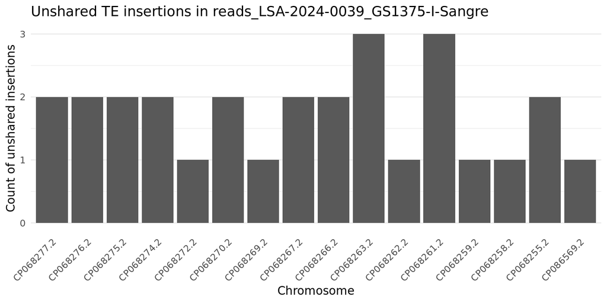

## Sample 2

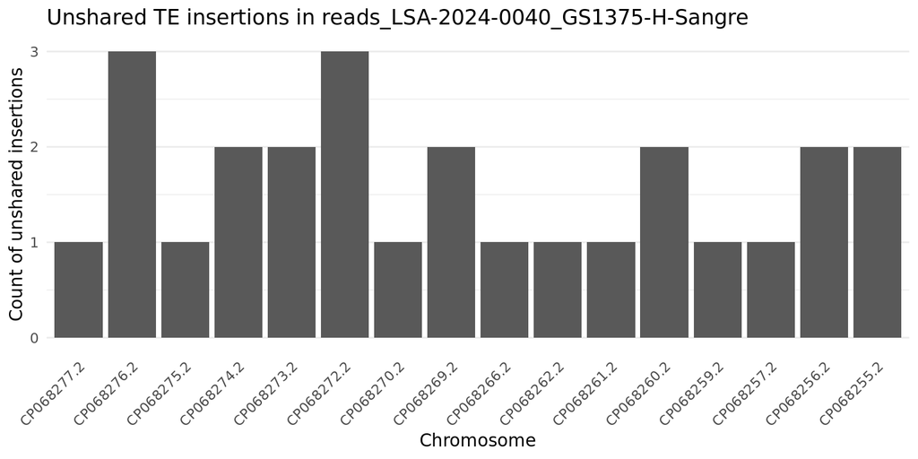

# Shared insertions

With the same methodology than the one used for unshared insertions (checking also for calls that did not pass the strict criterion), 1 904 are reported as shared between both samples.

## Shared insertions by class

| Class | Family | Subfamily | Number of insertions |
| --- | --- | --- | --- |
| Class I | DNA | hAT | 6 |
|  |  | TcMar | 2 |
| Class II | LINE | L1 | 213 |
|  |  | L2 | 5 |
|  |  | CR1 | 1 |
|  | LTR | ERVK | 12 |
|  |  | ERVL | 18 |
|  |  | ERV1 | 68 |
|  | Retroposon | SVA | 224 |
|  | SINE | Alu | 1 353 |
|  |  | MIR | 2 |
| Total | - | - | 1 904 |

## Annotation of shared insertions

In the table below is shown the gene annotation for shared insertions.

**Click to show table with 1 154 rows.**

**Note**: Annotation type is as described by R package annotatr: “cds”: coding sequences, “promoter”: regulatory region up to 1kb uptream, “1to5kb”: regulatory region between 1 and 5kb upstream, “genes” and “introns”: literal meaning.

| Position | INS Id | Gene symbol | Gene Id | Annotation type |
| --- | --- | --- | --- | --- |
| CP068255.2:1 251 770 | seq99940 | ASMTL-AS1 | NR_026710.1 | introns |
|  |  | ASMTL | NM_001173474.2 | introns |
| CP068255.2:5 749 734 | seq100146 | NLGN4X | XM_054327452.1 | introns |
| CP068255.2:18 657 080 | seq100412 | ADGRG2 | XM_054326337.1 | introns |
| CP068255.2:22 237 816 | seq100470 | PTCHD1-AS | NR_073010.2 | introns |
| CP068255.2:24 293 358 | seq100519 | POLA1 | XM_054327253.1 | introns |
| CP068255.2:28 925 984 | seq100602 | IL1RAPL1 | NM_014271.4 | introns |
| CP068255.2:32 882 840 | seq100715 | DMD | NM_000109.4 | introns |
| CP068255.2:83 564 693 | seq101485 | SATL1 | NM_001367857.2 | introns |
| CP068255.2:83 656 505 | seq101488 | SATL1 | NM_001367857.2 | introns |
| CP068255.2:83 683 173 | seq101490 | ZNF711 | NM_001330574.2 | introns |
| CP068255.2:84 713 986 | seq101524 | DACH2 | XM_054326429.1 | introns |
| CP068255.2:90 623 038 | seq101694 | PCDH11X | NM_032968.5 | introns |
| CP068255.2:95 509 280 | seq101781 | DIAPH2 | NM_007309.4 | introns |
| CP068255.2:100 344 903 | seq101860 | ZMAT1 | NM_001011657.4 | introns |
| CP068255.2:110 764 583 | seq102009 | RTL4 | NM_001004308.3 | introns |
| CP068255.2:120 735 396 | seq102216 | LOC101928359 | XR_007091085.1 | introns |
| CP068255.2:135 342 456 | seq102534 | GPR101 | NM_054021.2 | promoters |
| CP068255.2:146 257 439 | seq102807 | FMR1NB | NM_152578.3 | introns |
| CP068255.2:295 086 | seq99844 | LOC102724521 | XR_008485519.1 | introns |
| CP068256.2:7 583 739 | seq97386 | LOC128966699 | XR_008485442.1 | promoters |
| CP068256.2:18 235 399 | seq98298 | SLC25A18 | NM_001303484.2 | introns |
|  |  | LOC105372850 | XR_007090425.1 | introns |
| CP068256.2:25 461 788 | seq98656 | KIAA1671 | NM_001386930.1 | introns |
| CP068256.2:27 234 737 | seq98743 | MIATNB | NR_110543.1 | introns |
| CP068256.2:28 841 478 | seq98782 | TTC28 | NM_001393404.1 | introns |
| CP068256.2:29 242 941 | seq98787 | CCDC117 | NM_001284263.2 | introns |
| CP068256.2:32 056 342 | seq98862 | SFI1 | NM_001258325.1 | introns |
| CP068256.2:32 276 540 | seq98870 | DEPDC5 | XM_054326198.1 | introns |
| CP068256.2:34 131 369 | seq98918 | LARGE1 | XR_008485436.1 | introns |

[output cut: 1124 more lines]

## Full list

This is the list of insertions found shared between both samples, alongside its allele frequency inside the whole population (all the cases in your pipeline) and which sample it was found in.

**Click to show table with 1 904 rows.**

| Position | seqId | Length (bp) | Type | Population allele frequency | Present in sample |
| --- | --- | --- | --- | --- | --- |
| CP068255.2:1 251 770 | seq99940 | 209 | SINE (AluJb) | 1.00 | reads_LSA-2024-0040_GS1375-H-Sangre |
| CP068255.2:1 251 770 | seq99940 | 209 | SINE (AluJb) | 1.00 | reads_LSA-2024-0039_GS1375-I-Sangre |
| CP068255.2:3 778 903 | seq100052 | 58 | LINE (L1PB1) | 0.50 | reads_LSA-2024-0039_GS1375-I-Sangre |
| CP068255.2:3 778 903 | seq100052 | 58 | LINE (L1PB1) | 0.50 | reads_LSA-2024-0040_GS1375-H-Sangre |
| CP068255.2:4 531 817 | seq100087 | 314 | SINE (AluYa5) | 0.50 | reads_LSA-2024-0040_GS1375-H-Sangre |
| CP068255.2:4 531 817 | seq100087 | 314 | SINE (AluYa5) | 0.50 | reads_LSA-2024-0039_GS1375-I-Sangre |
| CP068255.2:5 749 734 | seq100146 | 114 | SINE (AluY) | 0.50 | reads_LSA-2024-0039_GS1375-I-Sangre |
| CP068255.2:5 749 734 | seq100146 | 114 | SINE (AluY) | 0.50 | reads_LSA-2024-0040_GS1375-H-Sangre |
| CP068255.2:18 657 080 | seq100412 | 53 | SINE (AluJb) | 0.50 | reads_LSA-2024-0040_GS1375-H-Sangre |
| CP068255.2:18 657 080 | seq100412 | 53 | SINE (AluJb) | 0.50 | reads_LSA-2024-0039_GS1375-I-Sangre |
| CP068255.2:22 237 816 | seq100470 | 314 | SINE (AluY) | 0.50 | reads_LSA-2024-0039_GS1375-I-Sangre |
| CP068255.2:22 237 816 | seq100470 | 314 | SINE (AluY) | 0.50 | reads_LSA-2024-0040_GS1375-H-Sangre |
| CP068255.2:24 293 358 | seq100519 | 128 | Retroposon (SVA_F) | 1.00 | reads_LSA-2024-0040_GS1375-H-Sangre |
| CP068255.2:24 293 358 | seq100519 | 128 | Retroposon (SVA_F) | 1.00 | reads_LSA-2024-0039_GS1375-I-Sangre |
| CP068255.2:25 517 581 | seq100544 | 333 | SINE (AluYb8) | 1.00 | reads_LSA-2024-0039_GS1375-I-Sangre |
| CP068255.2:25 517 581 | seq100544 | 333 | SINE (AluYb8) | 1.00 | reads_LSA-2024-0040_GS1375-H-Sangre |
| CP068255.2:25 603 542 | seq100550 | 111 | LINE (L1M3) | 0.50 | reads_LSA-2024-0040_GS1375-H-Sangre |
| CP068255.2:27 034 647 | seq100570 | 90 | LTR (MER61C) | 0.50 | reads_LSA-2024-0039_GS1375-I-Sangre |
| CP068255.2:28 925 984 | seq100602 | 49 | Retroposon (SVA_F) | 0.75 | reads_LSA-2024-0040_GS1375-H-Sangre |
| CP068255.2:30 241 729 | seq100640 | 323 | SINE (AluYe5) | 0.50 | reads_LSA-2024-0039_GS1375-I-Sangre |
| CP068255.2:32 882 840 | seq100715 | 308 | SINE (AluY) | 0.50 | reads_LSA-2024-0040_GS1375-H-Sangre |
| CP068255.2:43 924 374 | seq100870 | 128 | SINE (FLAM_C) | 0.50 | reads_LSA-2024-0039_GS1375-I-Sangre |
| CP068255.2:45 683 112 | seq100907 | 125 | Retroposon (SVA_F) | 1.00 | reads_LSA-2024-0040_GS1375-H-Sangre |
| CP068255.2:51 222 384 | seq101011 | 317 | SINE (AluYa5) | 0.50 | reads_LSA-2024-0039_GS1375-I-Sangre |
| CP068255.2:52 216 963 | seq101024 | 324 | SINE (AluYb8) | 0.50 | reads_LSA-2024-0040_GS1375-H-Sangre |
| CP068255.2:54 531 361 | seq101064 | 904 | LINE (L1HS) | 0.25 | reads_LSA-2024-0039_GS1375-I-Sangre |
| CP068255.2:54 851 870 | seq101067 | 4 693 | LINE (L1HS) | 0.25 | reads_LSA-2024-0040_GS1375-H-Sangre |
| CP068255.2:56 310 478 | seq101097 | 309 | LINE (L1P2) | 0.50 | reads_LSA-2024-0039_GS1375-I-Sangre |
| CP068255.2:56 311 246 | seq101098 | 123 | LINE (L1P1) | 0.50 | reads_LSA-2024-0040_GS1375-H-Sangre |
| CP068255.2:69 349 478 | seq101246 | 335 | SINE (AluYb8) | 0.50 | reads_LSA-2024-0039_GS1375-I-Sangre |

[output cut: 3726 more lines]